# IIV in circadian rhythms

## Comparing within-individual variation across treatment groups and time on which startle response duration was measured

```r
# Within-individual variation during PL treatment morning versus night
deltaVR_PL = VR_Day_PL - VR_Night_PL
# Within-individual variation during LD treatment morning versus night
deltaVR_LD = VR_Day_LD - VR_Night_LD
# Within-individual variation morning PL treatment versus LD treatment
deltaVR_Day = VID_Day_PL - VID_Day_LD
# Within-individual variation night PL treatment versus LD treatment
deltaVR_Night = VR_Night_PL - VR_Night_LD

WID<-data_frame(
   name = c("Day - Standard light", "Night - Standard light", "Day - ALAN", "Night - ALAN",deltas),
   mean =  c(posterior.mode(VID_Day_LD), posterior.mode(VID_Night_LD),
             posterior.mode(VID_Day_PL), posterior.mode(VID_Night_PL),
             posterior.mode(deltaVR_PL), posterior.mode(deltaVR_LD),
             posterior.mode(deltaVR_Day), posterior.mode(deltaVR_Night)),
   lower =  c(HPDinterval(VID_Day_LD)[1], HPDinterval(VID_Night_LD)[1],
              HPDinterval(VID_Day_PL)[1], HPDinterval(VID_Night_PL)[1],
              HPDinterval(deltaVR_PL)[1], HPDinterval(deltaVR_LD)[1],
              HPDinterval(deltaVR_Day)[1], HPDinterval(deltaVR_Night)[1]),
   upper =  c(HPDinterval(VID_Day_LD)[2], HPDinterval(VID_Night_LD)[2],
              HPDinterval(VID_Day_PL)[2], HPDinterval(VID_Night_PL)[2],
              HPDinterval(deltaVR_PL)[2], HPDinterval(deltaVR_LD)[2],
              HPDinterval(deltaVR_Day)[2], HPDinterval(deltaVR_Night)[2]),
   Type = c("Repeatability", "Repeatability", "Repeatability",
            "Repeatability", "\u0394", "\u0394", "\u0394", "\u0394"),
   Color = c("#a37d0b", "#52514e","#f2b90f", "#d19f0a", "#eda909",
             "#7d786e", "#eda909", "#7d786e" ))

WID1 <-  WID %>%
  mutate(name = str_replace(name, "LD", "- Standard light"),
         name = str_replace(name, "PL", "- ALAN"),
         name = str_replace(name, "Δ ", "Δ - "),
         name = str_replace(name, "Δ - -", "Δ -"))
```

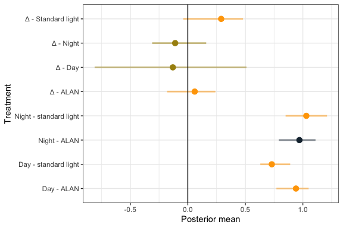

```r
plt3 <- ggplot(WID1, aes(x = name, y = mean, ymin = upper, ymax = lower)) +
   geom_linerange(aes(color =  name), size = 1, alpha = 0.5) +
   geom_point(aes(color = name), position=position_dodge(width=c(0.6,0.4)), size = 3) +
   coord_flip() + labs(y = "Posterior mean", x = "Treatment") +
   labs(colour= "Within-individual variation") +
   geom_hline(yintercept = 0)  +
   theme_bw()

plt3 +  scale_color_manual(values=c("orange", "orange","#172c3d", "orange",
                                  "orange", "#a88f0f", "#a88f0f", "orange" )) +
   scale_fill_manual(values=c("orange", "orange","#172c3d", "orange",
                              "orange", "#a88f0f", "#a88f0f", "orange")) +
   theme(legend.position = "none")
```

```r
WID1 <- WID1 %>%
   mutate_at(c( "mean","lower", "upper"),as.numeric) %>%
   mutate_at(vars("mean","lower", "upper"), funs(round(., 3))) %>%
   select("name", "mean","lower", "upper")

repeat_WID1<- c("Repeatability estimate", paste0("\u0394", " Variance"))

htmlTable(as.data.frame(WID1[,-1]),
          header =   paste(c("Posterior mean","95% CI lower","95% CI upper")),
          rnames = paste(c(WID1$name)),
          rgroup = c(repeat_VID),
          n.rgroup = c(4, 4),
          #          col.rgroup = c(rows=c(AD1),"#c95400"),
          #          col.rgroup = c(rows=c(AD2),"#c95400"),
          caption="Table S10: Within-individual variation (VWI) and differences in VWI (∆V) in startle response duration between treatment groups within time",
          tfoot= "Differences between treatments and time (∆V) was estimated as ALAN - Standard light and was Day - Night")
```

| Table S10: Within-individual variation (VWI) and differences in VWI (∆V) in startle response duration between treatment groups within time | Table S10: Within-individual variation (VWI) and differences in VWI (∆V) in startle response duration between treatment groups within time Posterior mean | Table S10: Within-individual variation (VWI) and differences in VWI (∆V) in startle response duration between treatment groups within time 95% CI lower | Table S10: Within-individual variation (VWI) and differences in VWI (∆V) in startle response duration between treatment groups within time 95% CI upper |
| --- | --- | --- | --- |
| Repeatability estimate |  |  |  |
| Day - standard light | 0.73 | 0.63 | 0.89 |
| Night - standard light | 1.03 | 0.85 | 1.21 |
| Day - ALAN | 0.94 | 0.77 | 1.05 |
| Night - ALAN | 0.97 | 0.79 | 1.11 |
| Δ Variance |  |  |  |
| Δ - ALAN | 0.06 | -0.18 | 0.24 |
| Δ - Standard light | 0.29 | -0.04 | 0.48 |
| Δ - Day | -0.13 | -0.81 | 0.51 |
| Δ - Night | -0.11 | -0.31 | 0.16 |

Differences between treatments and time (∆V) was estimated as ALAN - Standard light and was Day - Night

# 3. The effect of ALAN on metabolic rate

To investigate the effect of light pollution on the behaviour of hermit crabs, a linear Linear mixed-effects model fit by REML. Metabolic rate was log-transformed (log<sub>10</sub> +1). To account for the cross-over effect, we built a model containing a random intercept (i.e. individuals) and random slopes (i.e. experimental period), indicating that individual slopes vary across different experimental periods).

```r
MR <- read_csv("data/MR_res.csv", col_types = cols(ID = col_character(),
     Period = col_character(), Time = col_character())) %>%
  mutate(metR = log10(`metabolic rate` +1 )) %>%
  arrange(desc(Treatment))


Period_int <- lmer(metR  ~ Treatment*Period*Treatment*Time +
                     (Period|ID),
                     data=MR)


MR_interact_res<- summary(Period_int)

MR_interact_res = MR_interact_res$coefficients %>%
  data.frame() %>%
  rownames_to_column("headings") %>%
  rename(`Pr(>|z|)` = `Pr...t..`) %>%
  mutate(across(where(is.numeric), round, 3)) %>%
  mutate(`Pr(>|z|)` = as.character(`Pr(>|z|)`)) %>%
  mutate(`Pr(>|z|)` = case_when(
    `Pr(>|z|)` < 0.0001 ~ "< 0.001",
     TRUE ~ `Pr(>|z|)`)) %>%
  mutate(headings = str_remove(headings, "2"),
         headings = str_remove(headings, "2"),
         headings = str_remove(headings, "LL")) %>%
  column_to_rownames("headings") %>%
  rename(Std.Error = Std..Error)




MR_interact_res_high <- which(MR_interact_res$`Pr(>|z|)` < 0.05 |
                        MR_interact_res$`Pr(>|z|)` == "< 0.001" )

MR_interact_res %>%
  kable(caption = "Table S11:Results of LMM, the interactive effect of ALAN, time of the day and cross-over design on metabolic rate") %>%
kable_styling(full_width = T) %>%
  row_spec(MR_interact_res_high, bold = T) %>%
    footnote(general = "Reference values: Treatment – ALAN; Period – B; Time - PM")
```

Table S11:Results of LMM, the interactive effect of ALAN, time of the day and cross-over design on metabolic rate

|  | Estimate | Std.Error | df | t.value | Pr(>\|z\|) |
| --- | --- | --- | --- | --- | --- |
| (Intercept) | 0.477 | 0.166 | 19.559 | 2.870 | < 0.001 |
| Treatment | 0.977 | 0.235 | 19.559 | 4.159 | < 0.001 |
| Period | 0.520 | 0.245 | 26.801 | 2.122 | < 0.001 |
| Time | -0.142 | 0.212 | 23.999 | -0.670 | < 0.001 |
| Treatment:Period | -1.177 | 0.386 | 15.399 | -3.047 | < 0.001 |
| Treatment:Time | -0.395 | 0.299 | 23.999 | -1.319 | < 0.001 |
| Period:Time | 0.103 | 0.299 | 23.999 | 0.344 | < 0.001 |
| Treatment:Period:Time | 0.627 | 0.423 | 23.999 | 1.482 | < 0.001 |

Note:  
Reference values: Treatment – ALAN; Period – B; Time - PM

As the MCMCglmm model did not achieve convergence when we specified an interaction between treatment group and haemocyanin, we test its effect independently. We used t-test as haemocyanin concentration was performed in a single animal at the end of the experiment.

```r
lightdark_tst <- lightdark %>%
  group_by(treatment, obs) %>%
  summarise(haemoporc = mean(haemoporc))

haemo_test <- t.test(log(haemoporc) ~ treatment,
                     data = lightdark_tst, var.equal = FALSE,
                      alternative = c("two.sided")) %>%
  tidy() %>%
  dplyr::select(t= statistic, df = parameter, p.value ) %>%
  mutate(across(where(is.numeric), round, 3)) %>%
  as.data.frame()

rownames(haemo_test) = "Haemocyanin concentration"

havemo_h <- which(haemo_test$`p.value` < 0.05 |
                        haemo_test$`p.value` == "< 0.001" )

haemo_test  %>%
  kable(caption = "Table S12: T-test results for the effect of treatent on Haemocyanin concentration") %>%
kable_styling(full_width = T) %>%
  row_spec(havemo_h, bold = T)
```

Table S12: T-test results for the effect of treatent on Haemocyanin concentration

|  | t | df | p.value |
| --- | --- | --- | --- |
| Haemocyanin concentration | -3.173 | 17.401 | 0.005 |

```r
Mt<- MR %>%
   group_by(Treatment) %>%
   ggplot(aes(y =log10(metR +1), x = Treatment, fill =Treatment)) +
   geom_boxplot(size = 0.8, width = 0.4) +
   labs(x = "", y = "Metabolic rate \n (log10 nmol O2 mg−1 h−1 STP)") +

   ylab(expression("Metabolic rate ("~log[10] ~ mg ^1 ~ h^"−1 STP"~")")) +
   scale_fill_manual(values=c("#b5c1cf", "#b5c1cf"),
                     labels = c("Day", "Night"),
                     name = "") +
   #guides(fill=FALSE)  +
   guides(fill = guide_legend(title = "Time")) +
   theme_classic(base_size = 12) +
   theme(legend.position="none",
         text = element_text(size=15),
         legend.key.size = unit(1, 'cm')) +
   #coord_flip() +
   scale_x_discrete(labels = c("Standard light", "ALAN"))

g1<- lightdark %>%
   group_by(treatment) %>%
   ggplot(aes(x =treatment, y = prediction, fill =srtime)) +
   geom_boxplot(size = 0.8, width = 0.4) +
   labs(x = "", y = "Starle response duration (s)") +
   scale_fill_manual(values=c("orange", "#3c6a8f"),
                     labels = c("Day", "Night"), name = "") +
   #guides(fill=FALSE)  +
   #scale_x_discrete(labels = c("Standard light", "ALAN")) +
   theme_classic(base_size = 12) +
   theme(legend.position="top",
         text = element_text(size=15),
         legend.key.size = unit(1, 'cm'))+
   scale_x_discrete(labels = c("Standard light", "ALAN"))


haec <- lightdark %>%
  group_by(treatment, obs) %>%
  summarise(haemoporc = mean(haemoporc)) %>%
   ggplot(aes(x =treatment, y = haemoporc, fill =treatment )) +
   geom_boxplot(size = 0.8, width = 0.4) +
   labs( y = expression(paste("Haemocyanin concentration (mMol ", 1^-1, ")")),
         x = "") +

   scale_fill_manual(values=c("#b5c1cf", "#b5c1cf"),
                     labels = c("Day", "Night"),
                     name = "") +
   #guides(fill=FALSE)  +
   guides(fill = guide_legend(title = "Time")) +
   theme_classic(base_size = 12) +
   theme(legend.position="none",
         text = element_text(size=15),
         legend.key.size = unit(1, 'cm')) +
   #coord_flip() +
   scale_x_discrete(labels = c("Standard light", "ALAN"))


ggarrange(g1, Mt, haec,
          heights = c(1, 1,1),
          widths = c(1.2,1,1),
          ncols = 3, nrows = 1,
          #labels=c('A', 'B', 'C'),
          common.legend = F)

ggsave("g2.png",
        units="in", width=12, height= 9, dpi=600)
```

[figure not shown]

*Fig S5.* The effect of ALAN on (A) boldness, the (B) metabolic rate (MO2) and (C) haemocyanin concentration (mMol 1<sup>-1</sup>) in *Pagurus bernhardus*. Metabolic rate is expressed as log<sup>10</sup> nmol O<sub>2</sub> mg<sup>−1</sup> h<sup>−1 STP</sup>

# Session info

```
##  setting  value
##  version  R version 4.1.2 (2021-11-01)
##  os       macOS Big Sur 10.16
##  system   x86_64, darwin17.0
##  ui       X11
##  language (EN)
##  collate  en_AU.UTF-8
##  ctype    en_AU.UTF-8
##  tz       Australia/Melbourne
##  date     2022-03-10
##  pandoc   2.14.0.3 @ /Applications/RStudio.app/Contents/MacOS/pandoc/ (via rmarkdown)
```